# Analysis of Vehicular Crashes in Iowa

##### Nathan Rethwisch and Zack Swayne

##### December 6, 2022

##### DS 202

## Introduction

According to the Iowa Department of Transportation, there are over 50,000 crashes per year<sub>1</sub>. These crashes cause millions in property damage, and unfortunately, the loss of life, with over 300 people dying to vehicular crashes per year. It is important to gain a greater understanding of the causes of these crashes in order to better create prevention strategies and protect the drivers on the road. Furthermore, by informing drivers of potential hazardous practices, they will be better prepared and encouraged to follow safe driving practices. The goal of this report is to explore some of the correlations between crashes and driving conditions to gain a better understanding of how to make the road a safer place.

## The Data

This data set comes from the Iowa Department of Transportation contains data for every recorded vehicle crash since January 2009. It is updated monthly by the Iowa Department of Transportation,

Data cleaning included changing empty strings and illogical values into NA values. Day, month, and year values were extracted using R’s lubridate package. Latitude and longitude was columns were also created from the ‘Position’ column to further explore where crashes happen in Iowa.

## Sunrise/Sunset Analysis

After cleaning the data, our analysis focused on how time of the day when car crashes happen. We hypothesize that more crashes will happen in the morning and evening as the driver is travelling into the sun and has to deal with sun glare, preventing them from seeing clearly.

### Data Extraction

Because evening and morning times are variable throughout the year, one must look at when the sun is rising and setting. Because this data was not included in the original data set, the data was scraped from timeanddate.com<sub>2</sub>. The data includes sunrise and sunset times for Ames, Iowa in 2020. The reasoning behind using Ames was that it is the nearest major town to the geographical center of Iowa. This would limit variation of sunrise and sunset times based on location. For approximately every 70 miles, there is a one minute change in sunrise and sunset times. By using Ames, these discrepancies to under three minutes. The year 2020 was chosen because it is the most recent leap year and would provide meaningful data for February 29.

The table that was used for the data collection is as follows:

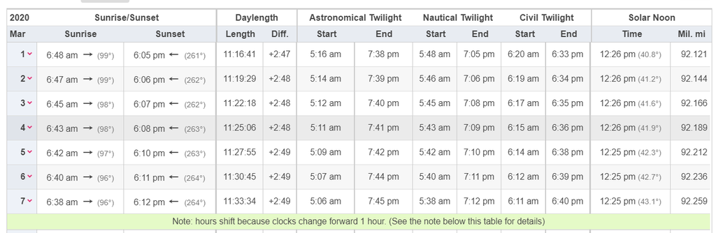

Using a function, the data was extracted for each month in 2020 and joined with the original crash data set.

### Sunrise/Sunset Analysis

The below graph shows the minutes from sunrise compared to number of crashes, with a line denoting when the sunrise time is:

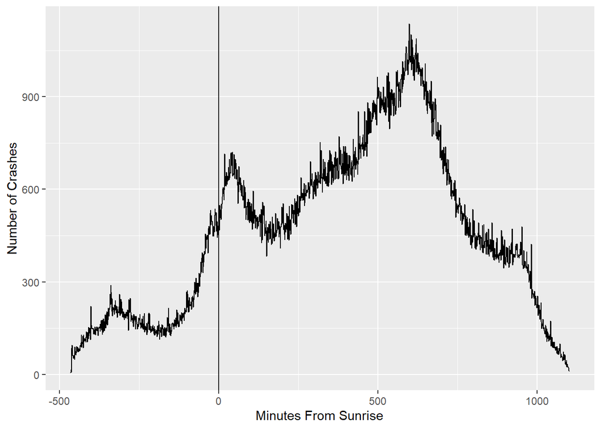

This clearly appears that there is a small spike, starting right before the sun rises.

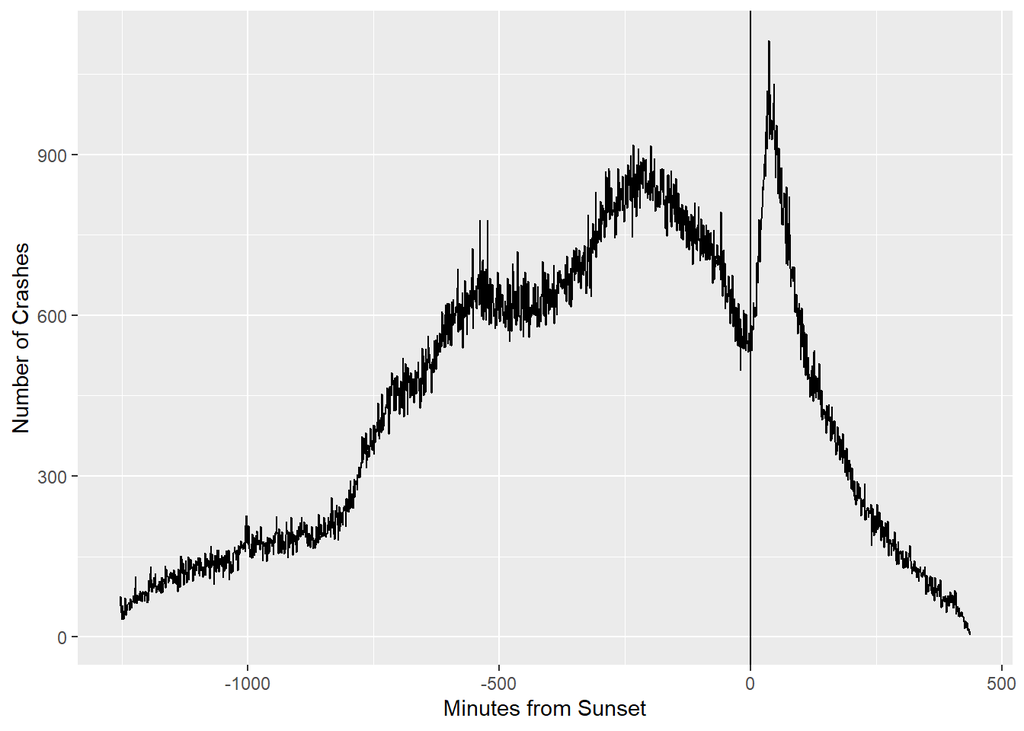

There appears to be a pretty drastic jump right after the sun sets. According to the Delaware Safety Council<sub>3</sub>, driving at dusk is extremely dangerous, as one’s eyes take time to adjust to the relative darkness, shadows hide animals and road features, and driver sometimes fail to turn on their headlights. This may be a reason why there is such a strong correlation between sunset time and a spike in car crashes.

### Daylight Analysis

One point of note is looking into how the length of the day affects car crashes. The following graph shows the number of crashes based on the length of the day. A line of best fit was added to the graph using LOESS smoothing.

There seems to be more variability in earlier months, but overall a downward trend.

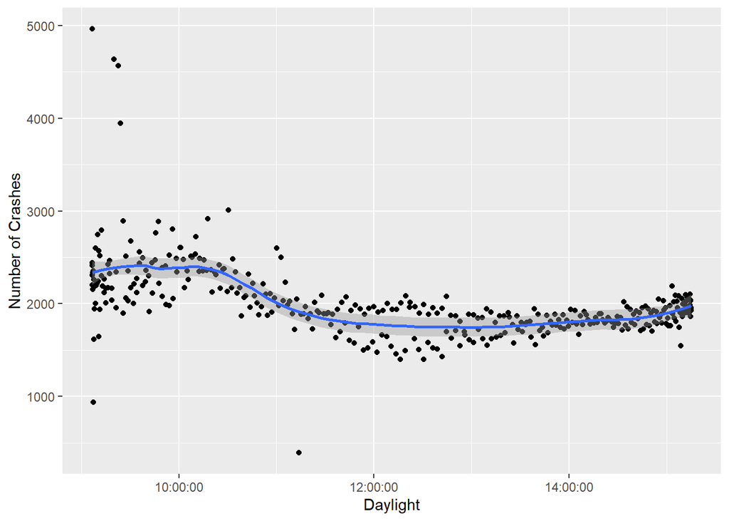

### Conclusion:

A number of conclusions can be drawn from this data analysis. First, we can conclude that there is a correlation between sunset and sunrise time and frequency of crashes. The 30-minute window after the sun sets, especially, is correlated with an increase in crashes in Iowa. There is also a correlation between higher numbers of crashes and fewer daylight hours, but this may be correlated with the winter months being more dangerous for drivers. For future research, we would like to to further look into how rush hour traffic may affect these trends.

## Alcohol Analysis

For my analysis, I would like to look into the relationship between alcohol and car crashes. I especially want to look into how the severity of car crashes and alcohol are related and what times are the most dangerous in terms of drunk drivers.

The main data set has a variable titled “Drug or Alcohol” with eight different levels. However, only two of these levels signify that substances were not involved. Because of this I created a helper variable titled “Drug_Usage” that is TRUE when there are substances involved and FALSE when there is none present.

In order to perform further calculations, I also created some helper variables containing the total of crashes with and without alcohol, respectively.

After that, I found the average property damage that results from crashes with and without drunk driving. As I expected, drunk crashes do cause more damage, almost $3000 more on average.

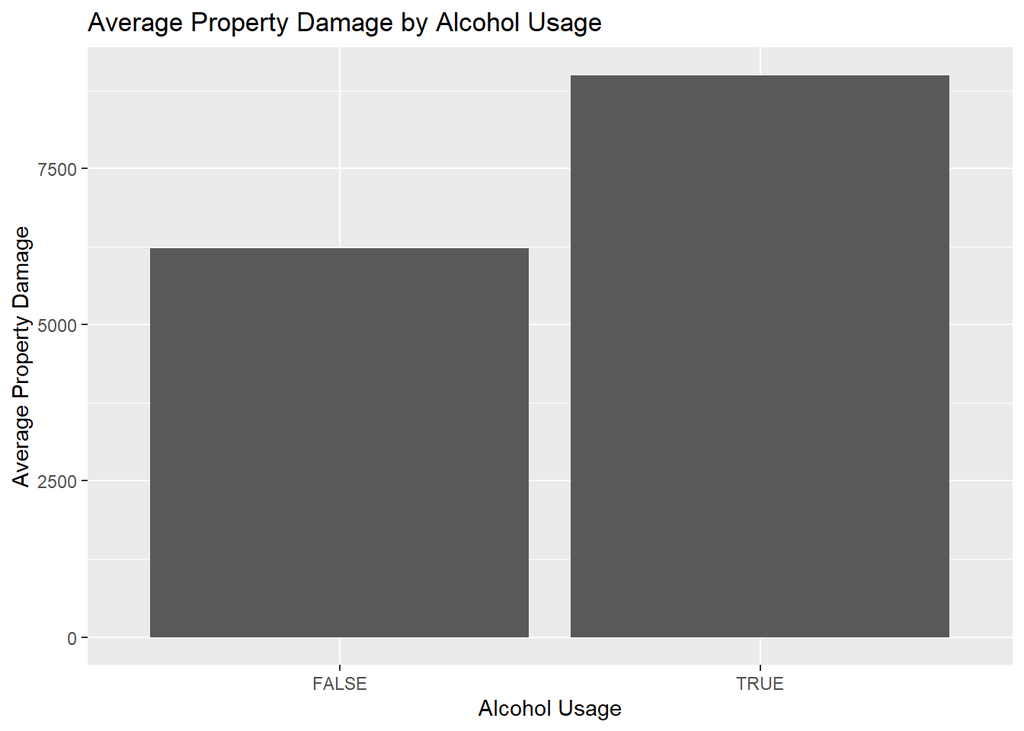

I also looked at the average fatalities per crash with and without alcohol. The actual values of the averages aren’t super intuitive, as they are small decimals, but finding the average rate of fatalities is much more useful. When doing so, fatalities occur in sober crashes about 1 in 217 crashes, while fatalities in drunk crashes occur at about 1 in 20. This difference in fatality is expected, but I am shocked at how much higher it truly is.

Next, I decided to look into how time of day affects drunk driving. I plotted sober and drunk crashes and tried to find a pattern.

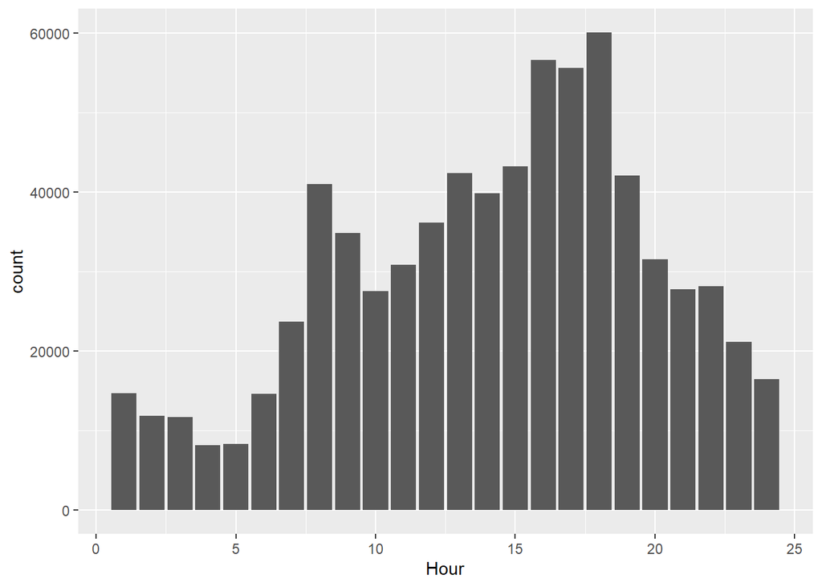

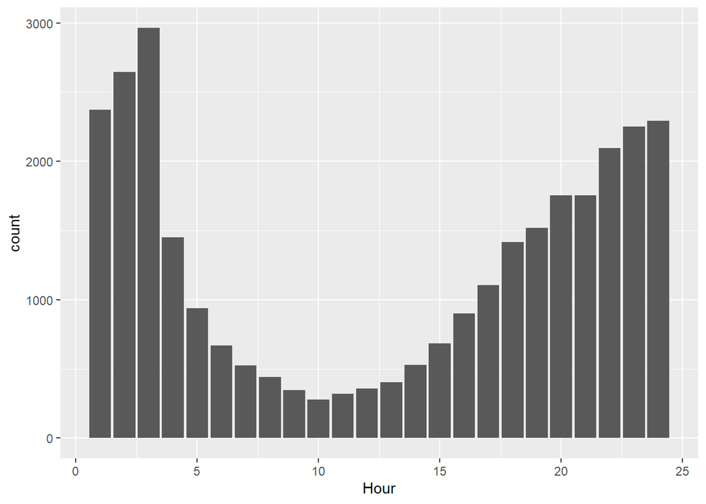

The next unit of time I decided to look at was day of the week. I expected to see a large spike on weekends, especially on Friday and Saturday. To do so, I once again plotted both sober and drunk crashes by day of the week and compared them.

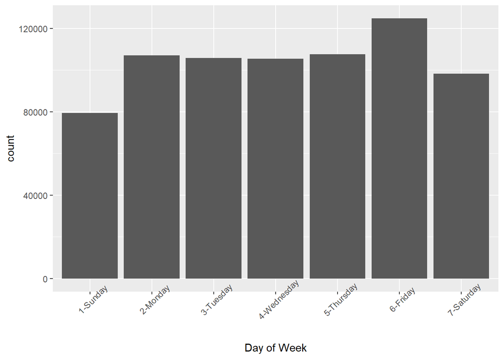

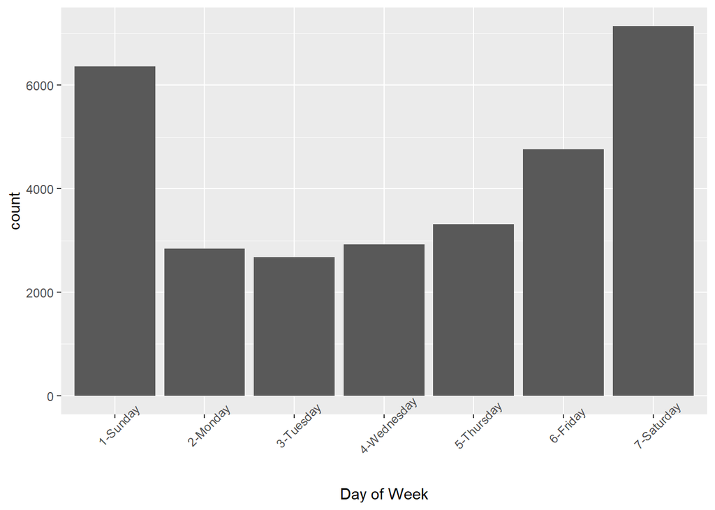

Finally, I looked at crashes by day of the year. There is no real pattern in by day of the year, but there are a few outliers. Both New Year’s day and the Fourth of July have a very large amount of drunk crashes in comparison to the rest of the year. This first graph shows all drug-related crashes:

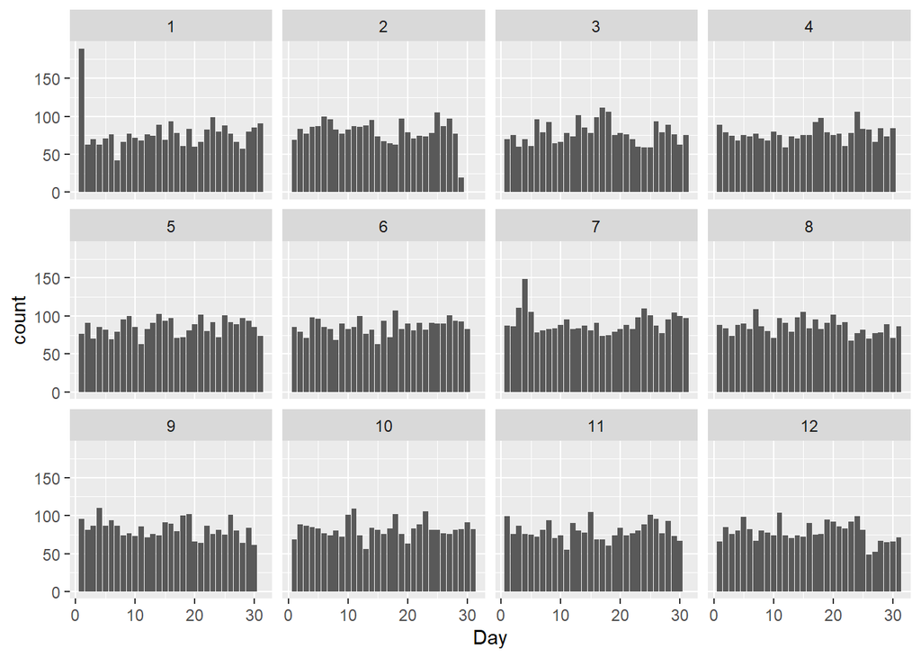

This graph shows all crashes in Iowa by day of year:

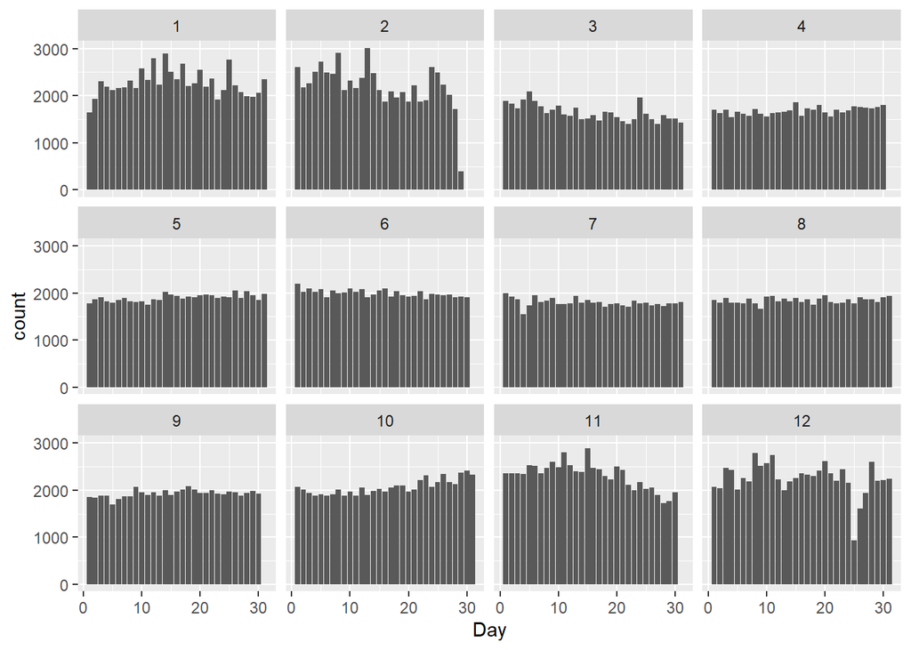

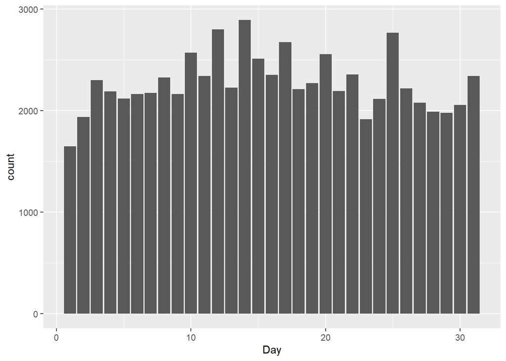

## Bibliography

1 “Iowa Motor Vehicle Crashes - 1925 to 2020” *Iowa Department of Transportation,* 2022, https://iowadot. gov/mvd/stats/crashhistory.pdf.

2 “Ames, Iowa, USA - sunrise, sunset, and daylength” *timeanddate*, https://www.timeanddate.com/ sun/@4846834?month=12&year=2020.

3 “Safe Driving Dusk and Dawn” *Delaware Safety Council,* https://delawaresafety.org/resources/ Documents/Safety%20Documents/Safe%20Driving%20-%20%20Dusk%20and%20Dawn.pdf.